# R Statistics

Pilar Amat Rodrigo

23/7/2018

# R Statistics (DataCamp II Courses)

## Introduction to Data

#### Types of variables

● Numerical (quantitative): numerical values

```
● Continuous:infinite number of values within a given range, often measured

● Discrete:specific set of numeric values that can be counted or enumerated, often counted.
```

● Categorical (qualitative): limited number of distinct categories.

```
● Ordinal:finite number of values within a given range, often measured

● Categorical data:

  - Often stored as factors in R

      - Important use: statistical modeling

      - Sometimes undesirable, sometimes essential

  - Common in subgroup analysis

      - where only interested in a subset of the data

      - filter for specific levels of categorical variable.
```

## Exploratory Analysis

### Exploring Categorical Data

We are going to work with comics dataset.Explore it.

```r
library(tidyverse)
```

```r
comics <- read.csv("Data/comics.csv")
glimpse(comics)
```

```
## Observations: 23,272
## Variables: 11
## $ name         <fct> Spider-Man (Peter Parker), Captain America (Steve...
## $ id           <fct> Secret, Public, Public, Public, No Dual, Public, ...
## $ align        <fct> Good, Good, Neutral, Good, Good, Good, Good, Good...
## $ eye          <fct> Hazel Eyes, Blue Eyes, Blue Eyes, Blue Eyes, Blue...
## $ hair         <fct> Brown Hair, White Hair, Black Hair, Black Hair, B...
## $ gender       <fct> Male, Male, Male, Male, Male, Male, Male, Male, M...
## $ gsm          <fct> NA, NA, NA, NA, NA, NA, NA, NA, NA, NA, NA, NA, N...
## $ alive        <fct> Living Characters, Living Characters, Living Char...
## $ appearances  <int> 4043, 3360, 3061, 2961, 2258, 2255, 2072, 2017, 1...
## $ first_appear <fct> Aug-62, Mar-41, Oct-74, Mar-63, Nov-50, Nov-61, N...
## $ publisher    <fct> marvel, marvel, marvel, marvel, marvel, marvel, m...
```

```r
head(comics)
```

```
##                                    name      id   align        eye
## 1             Spider-Man (Peter Parker)  Secret    Good Hazel Eyes
## 2       Captain America (Steven Rogers)  Public    Good  Blue Eyes
## 3 Wolverine (James \\"Logan\\" Howlett)  Public Neutral  Blue Eyes
## 4   Iron Man (Anthony \\"Tony\\" Stark)  Public    Good  Blue Eyes
## 5                   Thor (Thor Odinson) No Dual    Good  Blue Eyes
## 6            Benjamin Grimm (Earth-616)  Public    Good  Blue Eyes
##         hair gender  gsm             alive appearances first_appear
## 1 Brown Hair   Male <NA> Living Characters        4043       Aug-62
## 2 White Hair   Male <NA> Living Characters        3360       Mar-41
## 3 Black Hair   Male <NA> Living Characters        3061       Oct-74
## 4 Black Hair   Male <NA> Living Characters        2961       Mar-63
## 5 Blond Hair   Male <NA> Living Characters        2258       Nov-50
## 6    No Hair   Male <NA> Living Characters        2255       Nov-61
##   publisher
## 1    marvel
## 2    marvel
## 3    marvel
## 4    marvel
## 5    marvel
## 6    marvel
```

```r
levels(comics$align)
```

```
## [1] "Bad"                "Good"               "Neutral"
## [4] "Reformed Criminals"
```

```r
levels(comics$gender)
```

```
## [1] "Female" "Male"   "Other"
```

```r
table(comics$gender,comics$align)
```

```
##
##           Bad Good Neutral Reformed Criminals
##   Female 1573 2490     836                  1
##   Male   7561 4809    1799                  2
##   Other    32   17      17                  0
```

#### Drop levels

The contingency table from the last exercise revealed that there are some levels that have very low counts. To simplify the analysis, it often helps to drop such levels.

In R, this requires two steps: first filtering out any rows with the levels that have very low counts, then removing these levels from the factor variable with **droplevels()**. This is because the **droplevels()** function would keep levels that have just 1 or 2 counts; it only drops levels that don’t exist in a dataset.

Load the *dplyr package*. Print tab to find out which level of align has the fewest total entries. Use filter() to filter out all rows of comics with that level, then drop the unused level with **droplevels()**. Save the simplifed dataset over the old one as comics.

```r
library(dplyr)
```

```r
#Filter data from Reformed Criminals
comics<-comics %>% filter(align!= "Reformed Criminals") %>% droplevels()
```

#### Side-by-side barcharts

While a contingency table represents the counts numerically, it’s often more useful to represent them graphically.

This shows that there can often be two or more options for presenting the same data. Passing the argument **position = “dodge”** to **geom_bar()** says that you want a **side-by-side** (i.e. not stacked) barchart.

```
- Load the ggplot2 package.
- Create a side-by-side barchart with align on the x-axis and gender as the fill aesthetic.
- Create another side-by-side barchart with gender on the x-axis and align as the fill aesthetic. Rotate the axis labels 90 degrees to help readability.
```

```r
# Load ggplot2
library(ggplot2)
```

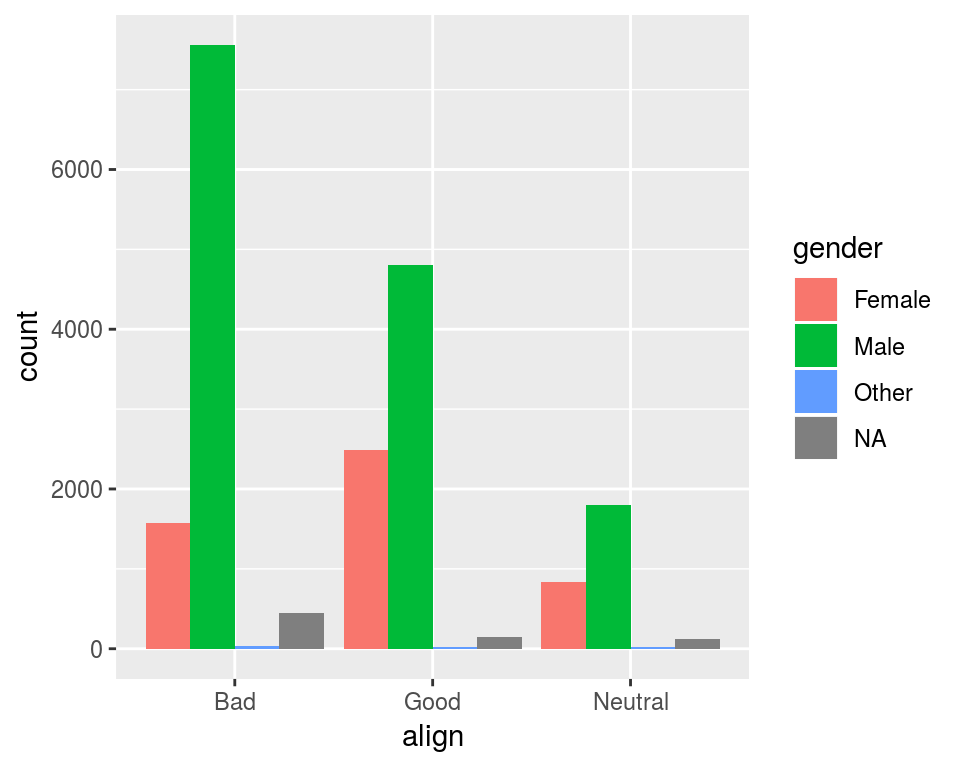

```r
# Create side-by-side barchart of gender by alignment
ggplot(comics, aes(x = align, fill =gender)) +
  geom_bar(position = "dodge")
```

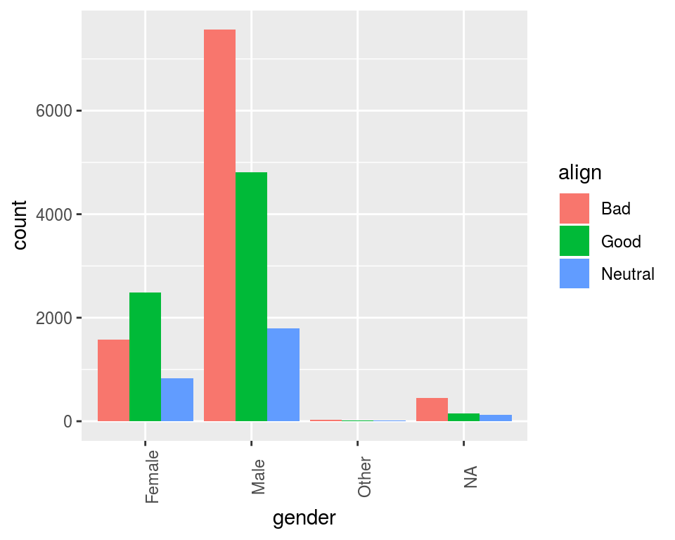

```r
# Create side-by-side barchart of alignment by gender

ggplot(comics, aes(x = gender, fill = align)) +
  geom_bar(position="dodge") +
  theme(axis.text.x = element_text(angle = 90))
```

#### Count vs proportions.

```r
(tab <- table(comics$align, comics$gender))
```

```
##
##           Female Male Other
##   Bad       1573 7561    32
##   Good      2490 4809    17
##   Neutral    836 1799    17
```

```r
options(scipen = 999, digits = 3) # Print fewer digits
prop.table(tab)     # Joint proportions
```

```
##
##             Female     Male    Other
##   Bad     0.082210 0.395160 0.001672
##   Good    0.130135 0.251333 0.000888
##   Neutral 0.043692 0.094021 0.000888
```

```r
prop.table(tab, 2)  # Conditional on columns
```

```
##
##           Female  Male Other
##   Bad      0.321 0.534 0.485
##   Good     0.508 0.339 0.258
##   Neutral  0.171 0.127 0.258
```

```r
prop.table(tab, 1)  # Conditional on rows
```

```
##
##            Female    Male   Other
##   Bad     0.17161 0.82490 0.00349
##   Good    0.34035 0.65733 0.00232
##   Neutral 0.31523 0.67836 0.00641
```

**Bar charts** can tell dramatically different stories depending on whether they represent counts or proportions and, if proportions, what the proportions are conditioned on. To demonstrate this difference, you’ll construct two barcharts in this exercise: one of counts and one of proportions.

By adding **position = “fill” to geom_bar()**, you are saying you want the bars to fill the entire height of the plotting window, thus displaying proportions and not raw counts.

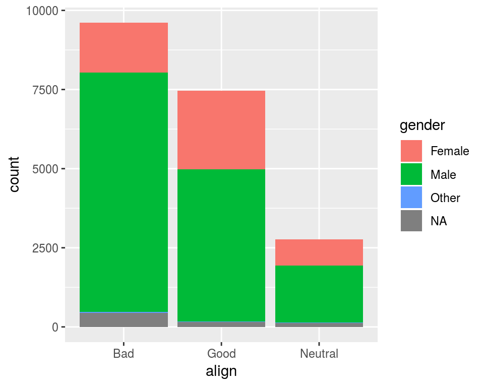

```r
# Plot of gender by align
ggplot(comics, aes(x = align, fill = gender)) +
  geom_bar()
```

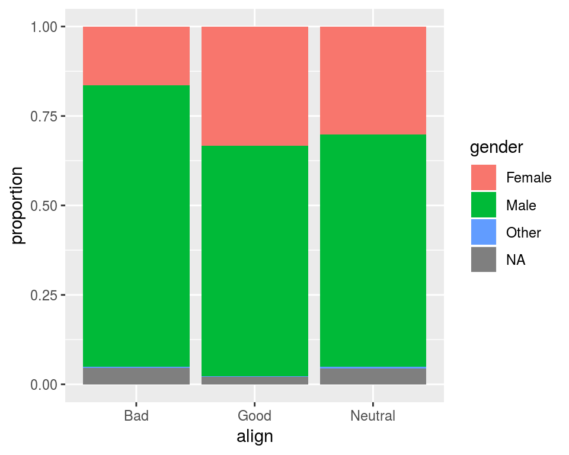

```r
# Plot proportion of gender, conditional on align
ggplot(comics, aes(x = align, fill = gender)) +
  geom_bar(position = "fill") +
  ylab("proportion")
```

#### Conditional Barcharts

**Faceting**

```r
(tab_cnt<- table(comics$id, comics$align))
```

```
##
##            Bad Good Neutral
##   No Dual  474  647     390
##   Public  2172 2930     965
##   Secret  4493 2475     959
##   Unknown    7    0       2
```

To represent this information broken by columns we can do a faceted ggplot

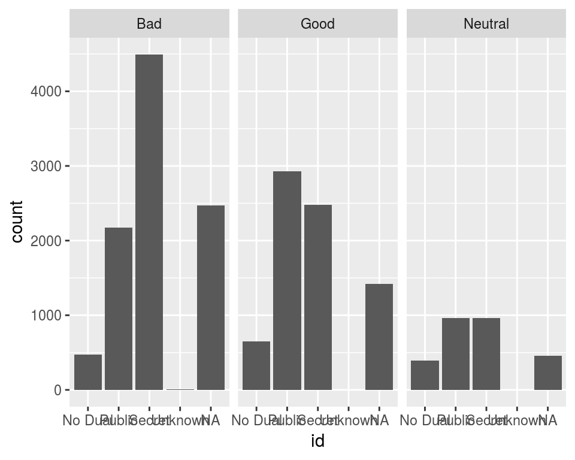

```r
ggplot(data = comics, aes(x= id)) +
  geom_bar()+
  facet_wrap(~align)
```

**Pie Chart**

The piechart is a very common way to represent the distribution of a single categorical variable, but they can be more difficult to interpret than barcharts.

```r
#lev <- c("apple", "key lime", "boston creme", "blueberry", "cherry", "pumpkin", "strawberry")
#pies$flavor <- factor(pies$flavor, levels = lev)

# Create barchart of flavor
#ggplot(pies, aes(x = flavor)) +
  #geom_bar(fill = "chartreuse") +
  #theme(axis.text.x = element_text(angle = 90))
```

### Exploring numerical data

#### Faceted histogram

With the cars dataset:

- Load the ggplot2 package.
- View the size of the data and the variable types using str().
- Plot a histogram of city_mpg faceted by suv, a logical variable indicating whether the car is an suv or not.

```r
library(ggplot2)
cars<- read_csv("Data/cars04.csv")
```

```r
str(cars)
```

[output not shown]

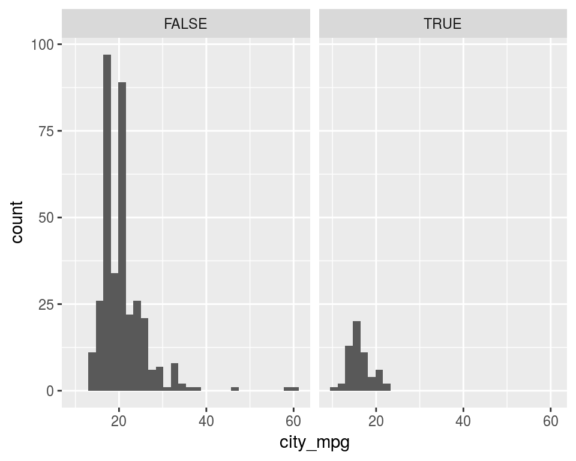

```r
ggplot(cars, aes(x = city_mpg)) +
  geom_histogram() +
  facet_wrap(~suv)
```

#### Boxplots and density plots

To explore the relationship between two variables, you could stick to using histograms, but in this exercise you’ll try your hand at two alternatives: the box plot and the density plot.

*Exercise* A quick look at unique(cars$ncyl) shows that there are more possible levels of ncyl than you might think. Here, restrict your attention to the most common levels.

- Filter cars to include only cars with 4, 6, or 8 cylinders and save the result as common_cyl. The %in% operator may prove useful here.
- Create side-by-side box plots of city_mpg separated out by ncyl.
- Create overlaid density plots of city_mpg colored by ncyl.

```r
library(dplyr)
library(ggplot2)
```

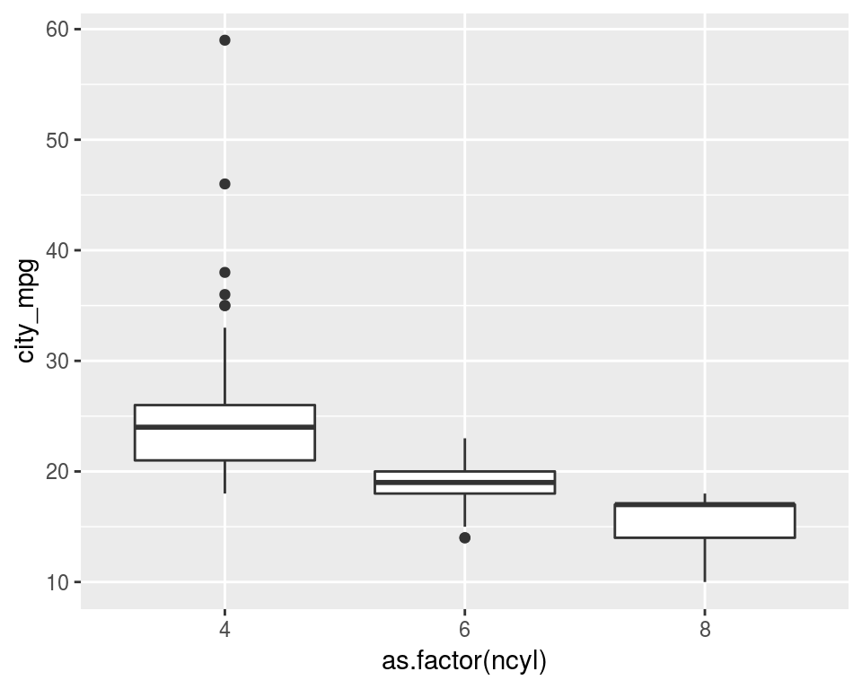

```r
  # Filter cars with 4, 6, 8 cylinders
common_cyl <- filter(cars, ncyl %in% c(4, 6, 8))

# Create box plots of city mpg by ncyl
ggplot(common_cyl, aes(x = as.factor(ncyl), y = city_mpg)) +
  geom_boxplot()
```

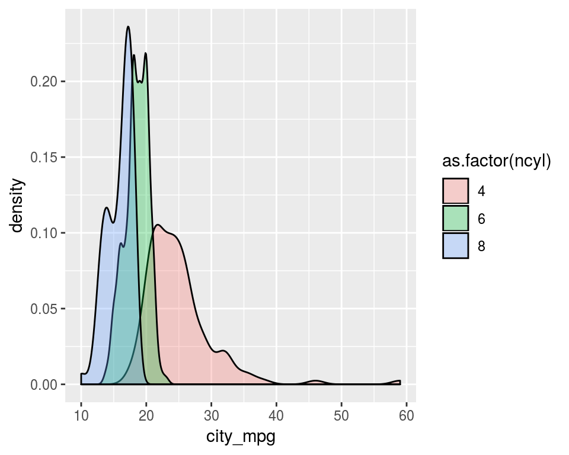

```r
# Create overlaid density plots for same data
ggplot(common_cyl, aes(x = city_mpg, fill = as.factor(ncyl))) +
  geom_density(alpha = .3)
```

*We can observe than variability in mileage of 8 cylinder cars is not similar to the variability of 4 cyl cars.*

**Outliers and Boxplots**

In addition to indicating the center and spread of a distribution, a box plot provides a graphical means to detect outliers.

*Exercise*

Construct a box plot of msrp. Exclude the largest 3-5 outliers by filtering the rows to retain cars less than $100,000. Save this reduced dataset as cars_no_out. *Construct a similar box plot of msrp using this reduced dataset. Compare the two plots.

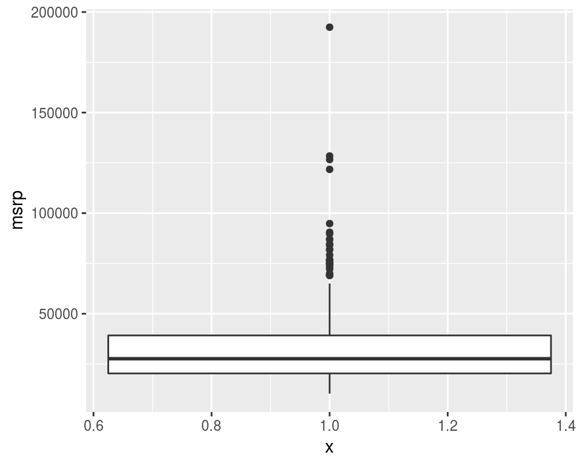

```r
# Construct box plot of msrp
cars %>%
  ggplot(aes(x = 1, y = msrp)) +
  geom_boxplot()
```

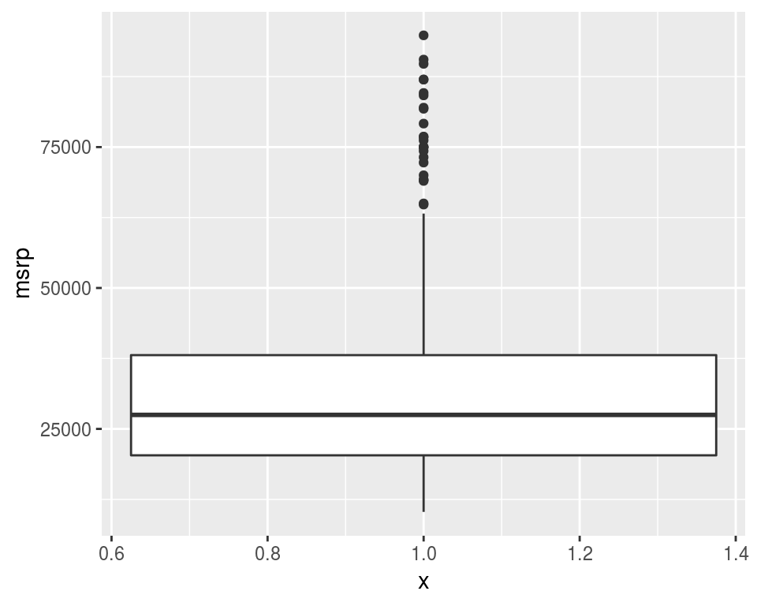

```r
# Exclude outliers from data
cars_no_out <- cars %>%
  filter(msrp < 100000)

# Construct box plot of msrp using the reduced dataset
cars_no_out %>%
  ggplot(aes(x = 1, y = msrp)) +
  geom_boxplot()
```

**Plot Selection**

Which is the most appropriate plot for displaying the important features of their distributions? Remember, both density plots and box plots display the central tendency and spread of the data, but the box plot is more robust to outliers.

### Numerical Summaries

Now that we’ve looked at exploring categorical and numerical data, you’ll learn some useful statistics for describing distributions of data. The choice of measure for center can have a dramatic impact on what we consider to be a typical observation, so it is important that you consider the shape of the distribution before deciding on the measure

```r
library(gapminder)
# Create dataset of 2007 data
gap2007 <- filter(gapminder, gapminder$year == "2007")

# Compute groupwise mean and median lifeExp
gap2007 %>%
  group_by(continent) %>%
  summarize(mean(lifeExp),
            median(lifeExp))
```

```
## # A tibble: 5 x 3
##   continent `mean(lifeExp)` `median(lifeExp)`
##   <fct>               <dbl>             <dbl>
## 1 Africa               54.8              52.9
## 2 Americas             73.6              72.9
## 3 Asia                 70.7              72.4
## 4 Europe               77.6              78.6
## 5 Oceania              80.7              80.7
```

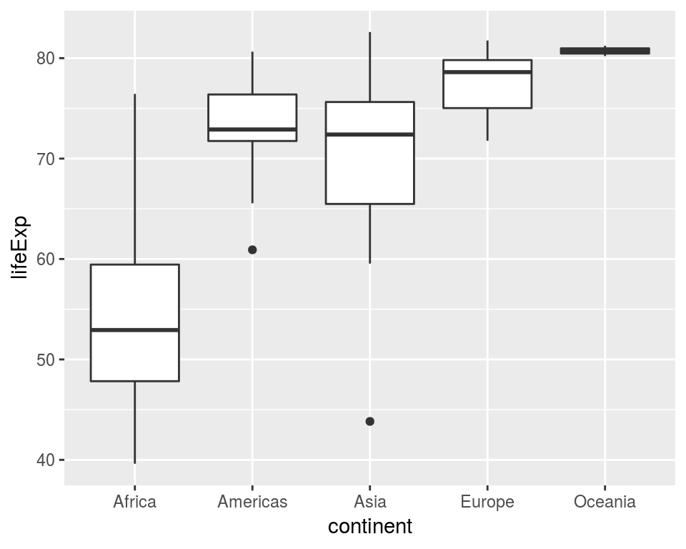

```r
# Generate box plots of lifeExp for each continent
gap2007 %>%
  ggplot(aes(x = continent, y = lifeExp)) +
  geom_boxplot()
```

#### Calculate Center Measures: SPREAD MEASURE

A problem is that mean and standard deviation are not robust against outliers.

An alternative to mean and standard deviation are median and interquartile range (IQR). IQR is the difference between the third and first quartiles (a.k.a. the 75th and 25th quantiles). IQR is often reported using the “five-number summary,” which includes: minimum, first quartile, median, third quartile and maximum.

Like mean and standard deviation, **median and IQR measure** the central tendency and spread, respectively, but **are robust against outliers and non-normal data.** They have a couple of additional advantages:

- Outlier Identification.
- Skewness.

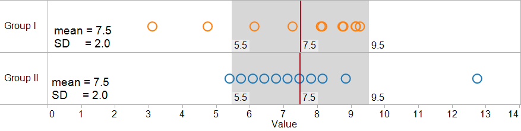

```r
knitr::include_graphics('Data/Anscombe1.png')
```

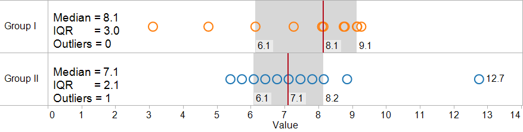

```r
knitr::include_graphics('Data/Anscombe2.png')
```

```r
# Compute groupwise measures of spread
gap2007 %>%
  group_by(continent) %>%
  summarize(sd(lifeExp),
            IQR(lifeExp),
            n())
```

```
## # A tibble: 5 x 4
##   continent `sd(lifeExp)` `IQR(lifeExp)` `n()`
##   <fct>             <dbl>          <dbl> <int>
## 1 Africa            9.63          11.6      52
## 2 Americas          4.44           4.63     25
## 3 Asia              7.96          10.2      33
## 4 Europe            2.98           4.78     30
## 5 Oceania           0.729          0.516     2
```

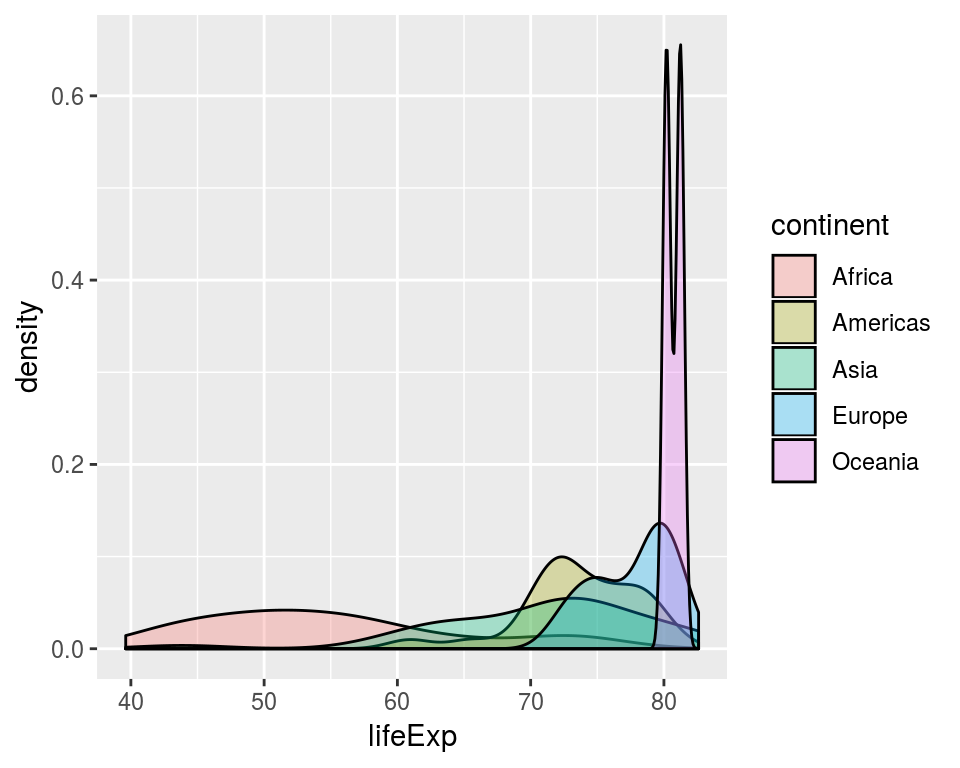

```r
# Generate overlaid density plots
gap2007 %>%
  ggplot(aes(x = lifeExp, fill = continent)) +
  geom_density(alpha = 0.3)
```

#### Shapes and transformations

Highly skewed distributions can make it very difficult to learn anything from a visualization. Transformations can be helpful in revealing the more subtle structure. Here you’ll focus on the population variable, which exhibits strong right skew, and transform it with the natural logarithm function (log() in R).

*Exercise*

Using the gap2007 data:

Create a density plot of the population variable. Mutate a new column called log_pop that is the natural log of the population and save it back into gap2007. Create a density plot of your transformed variable.

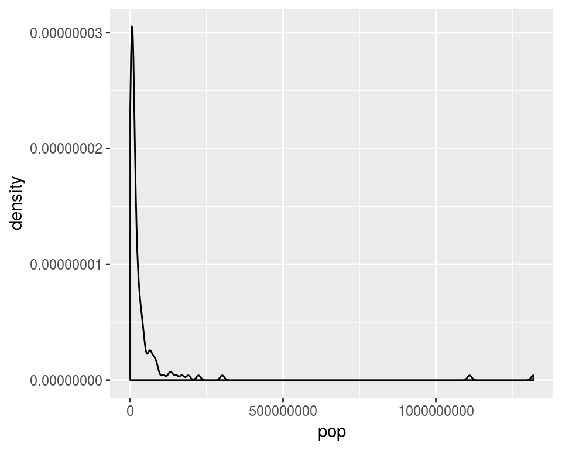

```r
gap2007 %>%
  ggplot(aes(x = pop)) +
  geom_density()
```

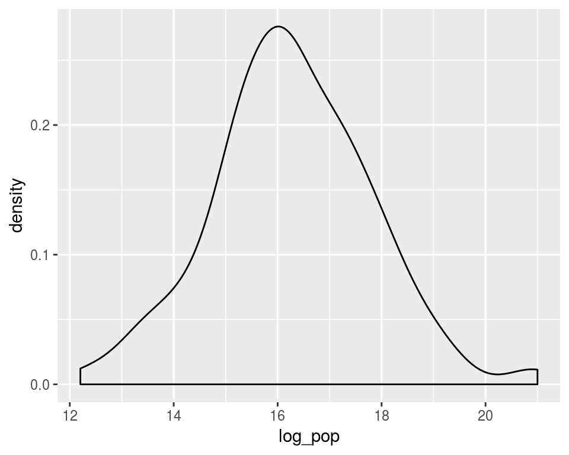

```r
# Transform the skewed pop variable
gap2007 <- gap2007 %>%
  mutate(log_pop = log(pop))

# Create density plot of new variable
gap2007 %>%
  ggplot(aes(x = log_pop)) +
  geom_density()
```

**Removing Outliers**

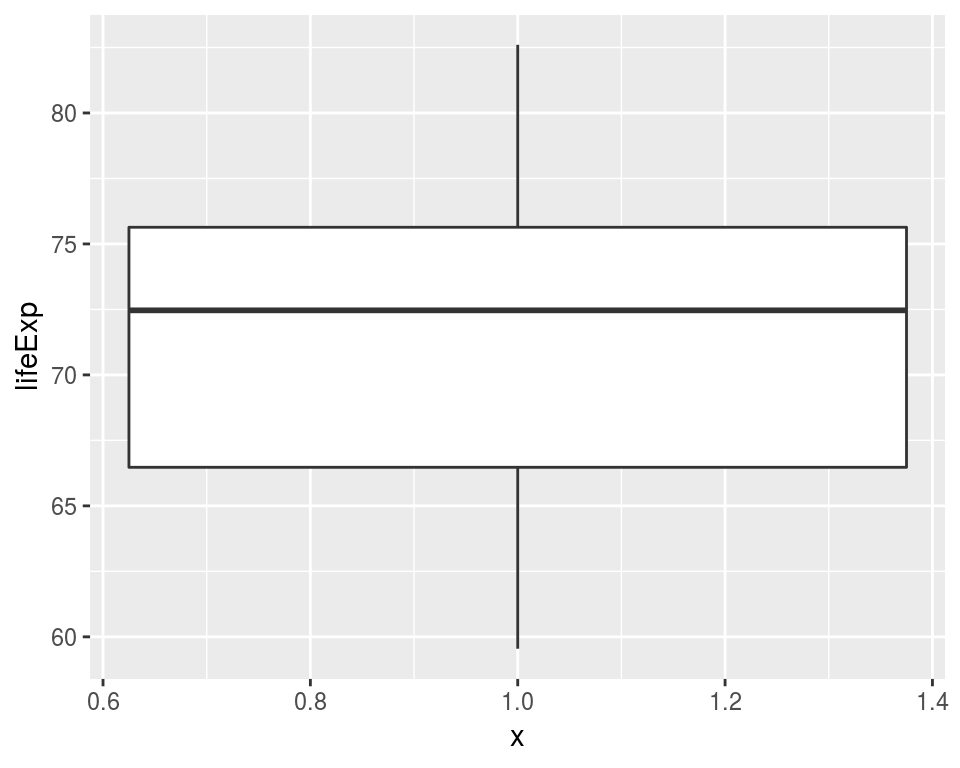

[output not shown]

```r
# Filter for Asia, add column indicating outliers
gap_asia <- gap2007 %>%
  filter(continent == "Asia") %>%
  mutate(is_outlier = lifeExp < 50)

# Remove outliers, create box plot of lifeExp
gap_asia %>%
  filter(!is_outlier) %>%
  ggplot(aes(x = 1, y = lifeExp)) +
  geom_boxplot()
```